# Sim_Exam1

Alex Blohm

10/11/2019

Libs

```r
library(tidyverse)
```

# 1. YAHTZEE!!!

Yahtzee is a game played with 5 dice. You can find the full rules here: https://en.wikipedia.org/wiki/Yahtzee

## (a) (10 points)

Write a function that simulates the rolling of 5 six-sided die. This function should return a vector of length 5.

```r
set.seed(42)
YAH_roll <- function(){
output <- replicate(n=5, ceiling(6*runif(1)))
return(output)
}
YAH_roll()
```

```
## [1] 6 6 2 5 4
```

## (b) (10 points)

A small straight occurs when four of the dice are sequential numbers. Using the function written in the previous part, estimate the probability using Monte Carlo simulation that you will roll a small straight on a SINGLE roll of the five dice (i.e. You roll all five dice once, and exactly four of them are sequential).

```r
Straights <- function(N){
  games <- replicate(YAH_roll(), n=N)

  f <- function(x) {
    sorted <- sort(x)
    Win <- (sorted[1] == sorted[2] - 1) & (sorted[1] == sorted[3] - 2) & (sorted[1] == sorted[4] -3) |
      (sorted[1] == sorted[3] - 1) & (sorted[1] == sorted[4] - 2) & (sorted[1] == sorted[5] -3) |
      (sorted[1] == sorted[2] - 1) & (sorted[1] == sorted[4] - 2) & (sorted[1] == sorted[5] -3) |
      (sorted[2] == sorted[3] - 1) & (sorted[2] == sorted[4] - 2) & (sorted[2] == sorted[5] -3)
    return(Win)
  }
apply(games, 2, f)
}
sum(Straights(N=10000)/10000)
```

```
## [1] 0.1545
```

## (c) (10 points)

Repeat the previous problem, but with a full house (i.e. three dice match and the other two dice match).

```r
FULL_House <- function(N){
  games <- replicate(YAH_roll(), n=N)

  f <- function(x) {
    sorted <- sort(x)
    if (sorted[1] == sorted[2] &
        sorted[2] == sorted[3] &
        sorted[3] == sorted[4] &
        sorted[4] == sorted[5]){
      Win <- F #Yahtzee
    }
    else{
    Win <- (sorted[1]==sorted[2] &
              sorted[3]==sorted[4] &
              sorted[4]==sorted[5] |
                        sorted[4]==sorted[5] &
                        sorted[1]==sorted[2] &
                        sorted[2]==sorted[3])
    }
    return(Win)
  }
apply(games, 2, f)
}

sum(FULL_House(N=100000)/100000)
```

```
## [1] 0.03804
```

## (d) (10points)

Repeat the previous problem, but estimate the probability that none of the five dice match on a single roll.

```r
NoMatch <- function(N){
  games <- replicate(YAH_roll(), n=N)

  f <- function(x) {
    sorted <- sort(x)
    if (sorted[1] != sorted[2] &
        sorted[2] != sorted[3] &
        sorted[3] != sorted[4] &
        sorted[4] != sorted[5]){
      Win <- T
    }
    else{
    Win <- F
    }
    return(Win)
  }
apply(games, 2, f)
}
sum(NoMatch(N=10000)/10000)
```

```
## [1] 0.0939
```

# 2. (20 points)

Write a function that will find roots of a function using the secant method. This function sholuld take in a function and a starting point and return the loction of a root. Use this function to find at least 5 roots of the function f(x) = sin(ex) + cos(e−x).

```r
secant_meth <- function(x0, f, n=20){
  x1 <- x0 + 0.01
  x <- c(x0, x1, rep(NA, n))
  for (i in (2:n)){
        x[i+1] <- x[i] - f(x[i])*(x[i]-x[i-1])/(f(x[i])-f(x[i-1]))
}
      return(x[n])
}

func<- function(x){ sin(exp(x)) + cos(exp(-x))}
secant_meth(0, func, n = 9)
```

```
## [1] -0.7212255
```

```r
secant_meth(1, func, n = 13)
```

```
## [1] 1.592457
```

```r
secant_meth(4, func, n = 14)
```

```
## [1] 4.007261
```

```r
secant_meth(5, func, n = 16)
```

```
## [1] 5.005415
```

```r
secant_meth(6, func, n = 20)
```

```
## [1] 6.008417
```

```r
secant_meth(10, func, n = 20)
```

```
## [1] 10.00743
```

```r
#xseq = seq(0, 100, .00001)
#yseq = func(xseq)
#data <- data.frame(xseq, yseq)
#ggplot(data = data, aes(x=xseq, y=yseq)) + geom_point(size=.001)
```

# 3. (10 points)

Write a function that generates random numbers between 0 and 1 using the Mersenne-Twister algoritm. Input to the function should be A, B, and m, and the function should return a random number between 0 and 1.

```r
Merc_Twisty <- function(seed = as.numeric(Sys.time()), leng = 1, m = 2^32, A = 1664525, B = 1013904223){
  x <- c(seed, rep(NA, leng))

  for (i in 1:leng){
    x[i + 1] <- (A*x[i] + B) %% m
  }
return(x[-1]/m)
}

Merc_Twisty(leng = 5)
```

```
## [1] 0.4268139 0.6199145 0.4965684 0.7808626 0.6157254
```

# 4. (10 points)

Using the function you wrote in the previous problem, write a function that randomly draws from a Frechet distribution (F (x) = P (X ≤ x) = e−x−α , x > 0) with parameter α using the inversion method.

$$F(x) = P(X \leq x) = e^{-x^{-\alpha}}, x > 0$$

Finding the Inverse:
$$x = e^{-y^{-\alpha}}$$
$$\iff log(x) = -y^{-\alpha}$$
$$\iff log(x^{-1}) = y^{-\alpha}$$
$$\iff log(x^{-1})^{-1/\alpha} = y$$

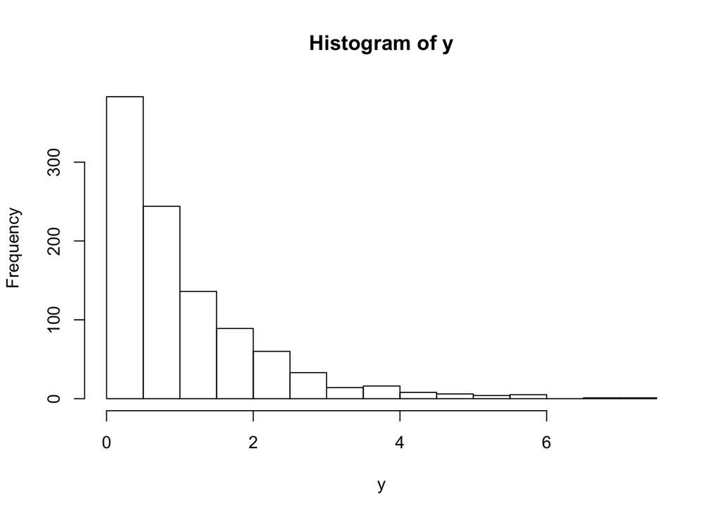

```r
finv <- function(x, alpha = 1){ log(x^(-1))^(1/alpha)}
u <- Merc_Twisty(leng = 1000)
y <- finv(u)
hist(y)
```

```r
#library(evd)
#hist(dfrechet(seq(0,10,.01), loc=0, scale=1, shape=1, log = FALSE) )
```

# 5. (20 points)

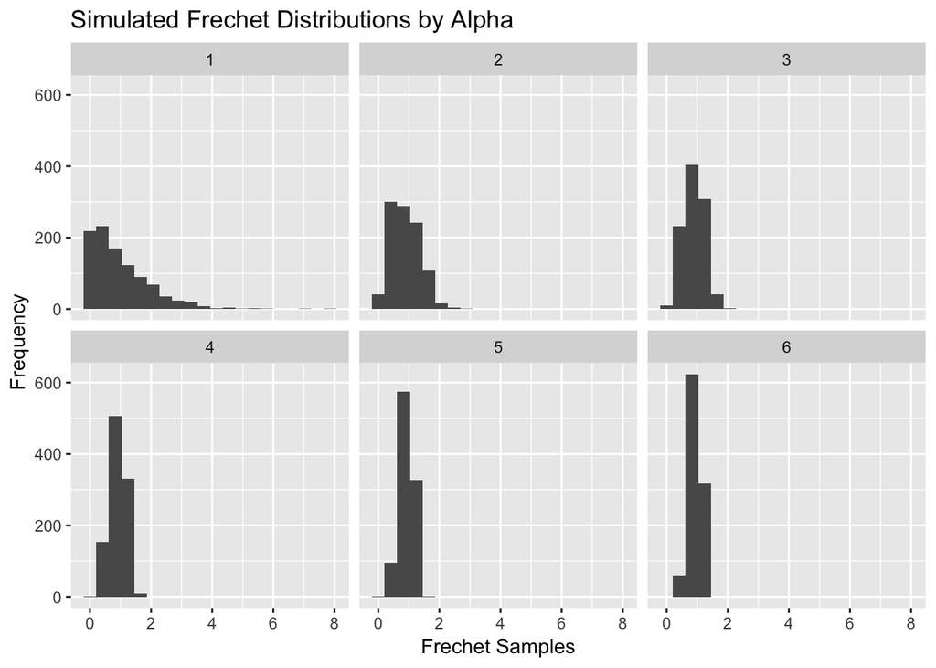

```r
u <- Merc_Twisty(leng = 1000)

v <- c(1:6)
names(v) <- c("Alpha = 1", "Alpha = 2", "Alpha = 3", "Alpha = 4", "Alpha = 5", "Alpha = 6")
outputs <- v %>% map(function(al){finv(u, alpha = al)}) %>% unlist()

alpha <- rep(c(1:6),1000) %>% sort()

resultsdf <- data.frame(outputs, alpha)

ggplot(resultsdf, aes(x=outputs, group = alpha)) +
  geom_histogram(bins = 20) +
  facet_wrap(alpha) +
  xlab("Frechet Samples") +
  ylab("Frequency") +
  ggtitle("Simulated Frechet Distributions by Alpha")
```